# Factor Analysis

F.A. Barrios, Ph.D.

2024-10-28

## Factor analysis introduction.

Factor analysis operates on the principle that observed variables are influenced by unobserved, latent factors. The main objectives of this technique include:  
1. Identifying the number of underlying factors.  
2. Determining the relationship between variables and factors.  
3. Interpreting the meaning of these factors.  
4. Quantifying how well each variable represents a factor.

There are two primary types of factor analysis:  
Exploratory Factor Analysis (EFA): Used to uncover the underlying structure of a large set of variables without preconceived notions about the relationships.  
Confirmatory Factor Analysis (CFA): Used to test specific hypotheses about the relationship between observed variables and underlying factors.

## How to do a Factor Analysis.

The factor analysis process typically involves the following steps:  
1. Data Collection: Gather a large dataset with multiple variables.  
2. Factor Extraction: Use methods like Maximum Likelihood (ML) or Principal Axis Factoring (PAF) to extract factors.  
3. Determining Factor Numbers: Use techniques like scree plots to decide how many factors to retain.  
4. Factor Rotation: Apply rotation methods (e.g., Varimax) to improve interpretability of factors.  
5. Factor Loading Analysis: Examine the strength of relationships between variables and factors.

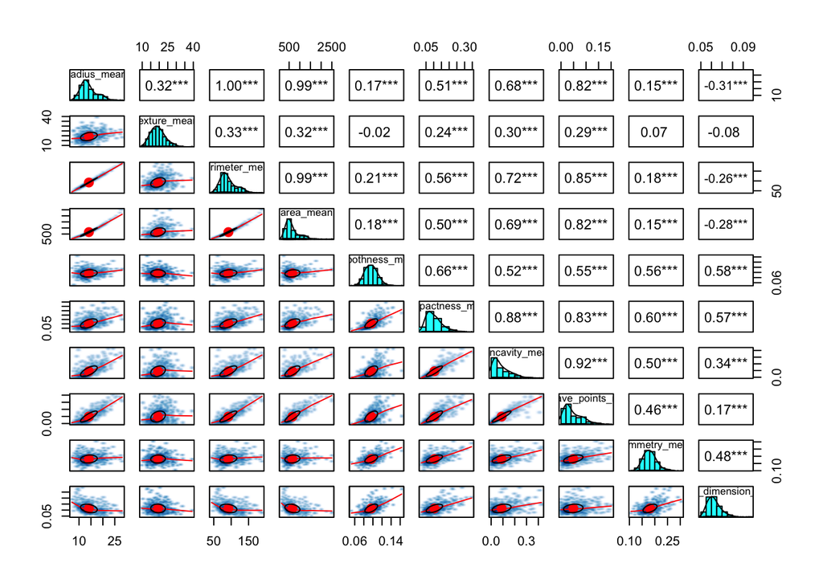

```r
wdbc <- read_csv("https://archive.ics.uci.edu/ml/machine-learning-databases/breast-cancer-wisconsin/wdbc.data",
                 col_names = FALSE, show_col_types = FALSE)

# The file comes without colume names, we will use features and qualifications.
features <- c("radius", "texture", "perimeter", "area", "smoothness", "compactness", "concavity",
              "concave_points", "symmetry", "fractal_dimension")
names(wdbc) <- c("id", "diagnosis", paste0(features,"_mean"), paste0(features,"_se"),
                 paste0(features,"_worst"))

# The data is used at Mike's PCA example.
# We will try the factor analysis subroutines with psych package

# Now for selection only the data without the ID and group
wdbc_all <- wdbc %>% select(-1, -2)
wdbc_mean <- wdbc_all %>% select(radius_mean:fractal_dimension_mean)

# First look at the variables in a correlation matrix
pairs.panels(wdbc_mean, pch = 21, stars = TRUE,  smoother = TRUE)
```

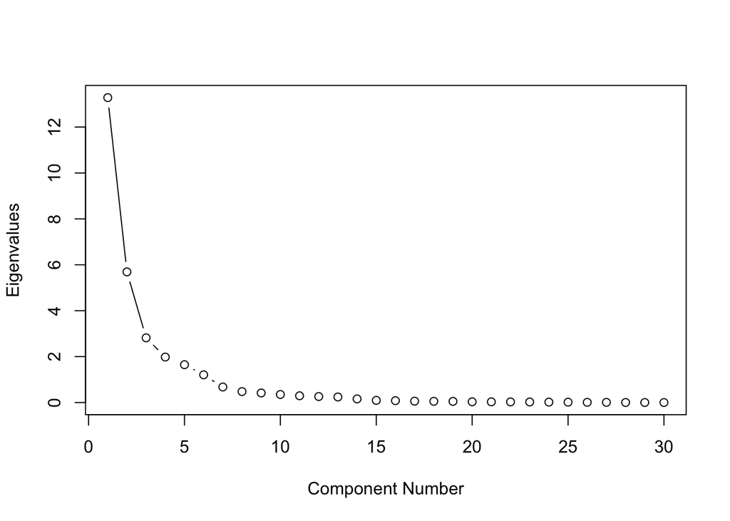

```r
# starting with latent variable exploratory factor analysis (EFA)
# the PCS for all
# principal(wdbc_all, 30, rotate = "none", scores = TRUE, cor = "cor", method = "regression")
pca_wdbc_all <- principal(wdbc_all, 30, rotate = "none", scores = TRUE, use ="pairwise", cor = "cor", covar = TRUE, method = "regression")
plot(pca_wdbc_all$values, type = "b", ylab = "Eigenvalues", xlab = "Component Number")
```

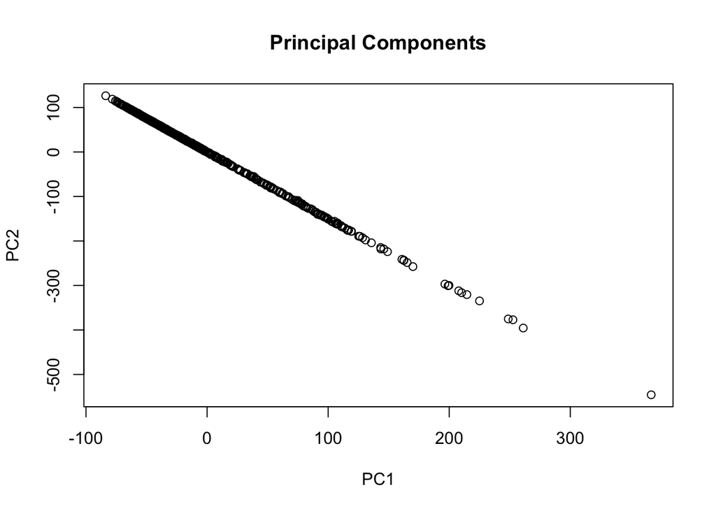

```r
scores_pca_wdbc <- pca_wdbc_all$scores
plot(scores_pca_wdbc[,1], scores_pca_wdbc[,2], xlab="PC1", ylab="PC2", main="Principal Components")
text(scores_pca_wdbc[,1], scores_pca_wdbc[,2], labels=rownames(scores_pca_wdbc), cex=0.7)
```

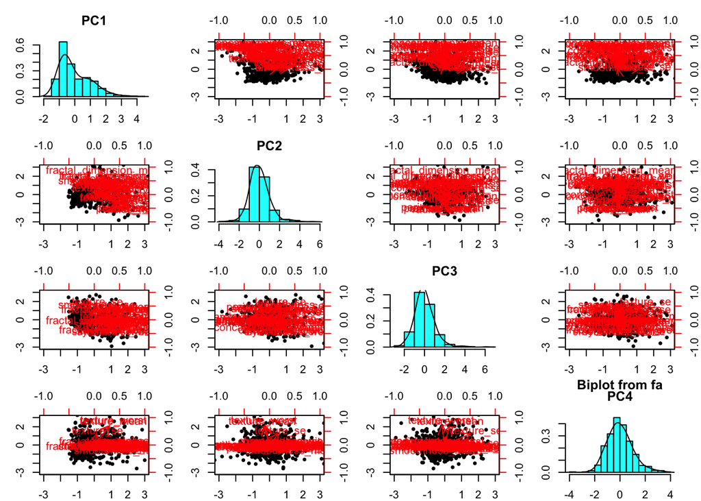

```r
pca_wdbc_4c <- principal(wdbc_all, 4, rotate = "none", scores = TRUE, cor = "cor", method = "regression")
biplot(pca_wdbc_4c)
```

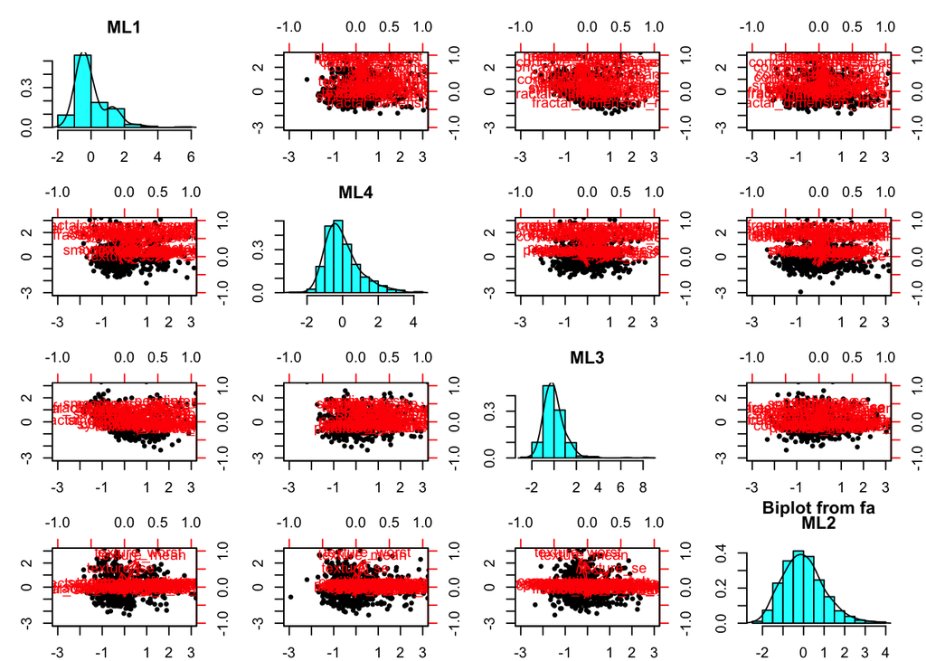

```r
fa_wdbc_4c <- fa(wdbc_all, 4, rotate="varimax", fm="ml", oblique.scores=TRUE)
biplot(fa_wdbc_4c)
```

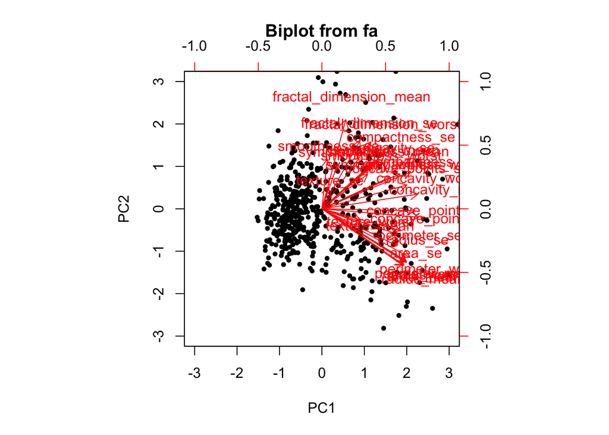

```r
pca_wdbc_2c <- principal(wdbc_all, 2, rotate = "none", scores = TRUE, cor = "cor", method = "regression")
biplot(pca_wdbc_2c)
```

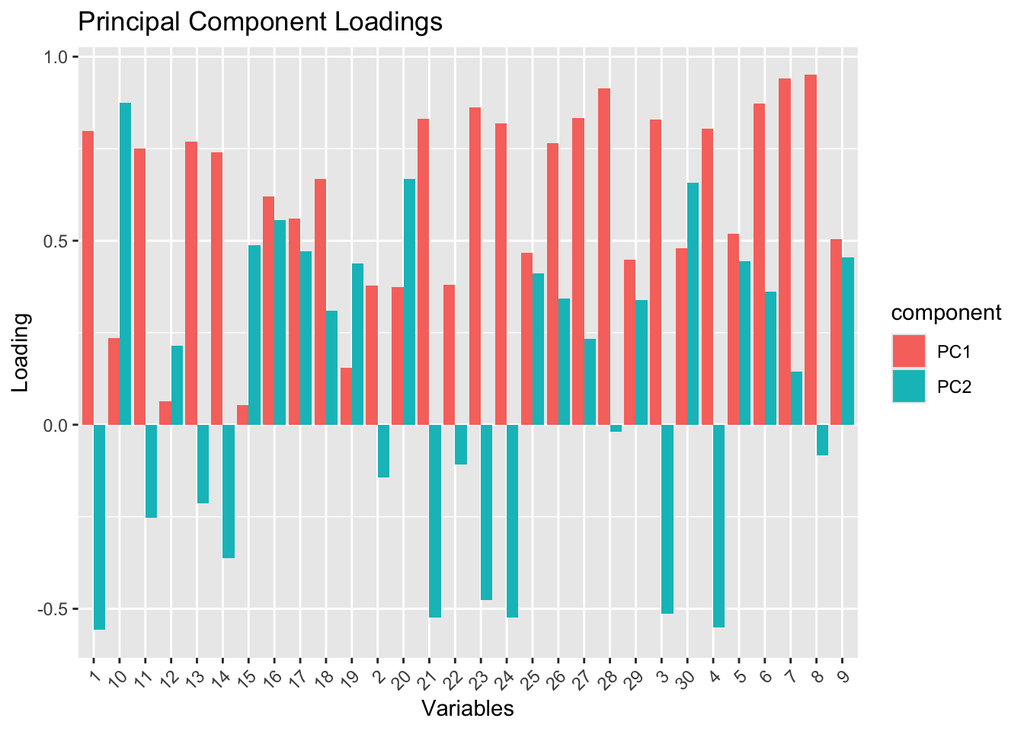

```r
pca_wdbc_2c_loadings_df <- as_tibble(pca_wdbc_2c$loadings[])
pca_wdbc_2c_loadings_df$variable <- rownames(pca_wdbc_2c_loadings_df)
pca_wdbc_2c_loadings_long <- pivot_longer(pca_wdbc_2c_loadings_df, -variable, names_to = "component", values_to = "loading")

ggplot(pca_wdbc_2c_loadings_long, aes(x = variable, y = loading, fill = component)) +
  geom_bar(stat = "identity", position = "dodge") +
  theme(axis.text.x = element_text(angle = 45, hjust = 1)) +
  labs(title = "Principal Component Loadings", x = "Variables", y = "Loading")
```

```r
fa(wdbc_mean, 2, rotate="varimax", fm="ml", oblique.scores=TRUE)
```

```
## Factor Analysis using method =  ml
## Call: fa(r = wdbc_mean, nfactors = 2, rotate = "varimax", fm = "ml",
##     oblique.scores = TRUE)
## Standardized loadings (pattern matrix) based upon correlation matrix
##                          ML1  ML2   h2     u2 com
## radius_mean             1.00 0.03 1.00 0.0028 1.0
## texture_mean            0.32 0.08 0.11 0.8895 1.1
## perimeter_mean          0.99 0.09 1.00 0.0026 1.0
## area_mean               0.99 0.04 0.98 0.0223 1.0
## smoothness_mean         0.14 0.72 0.54 0.4586 1.1
## compactness_mean        0.48 0.84 0.93 0.0655 1.6
## concavity_mean          0.66 0.68 0.89 0.1063 2.0
## concave_points_mean     0.81 0.54 0.94 0.0556 1.8
## symmetry_mean           0.13 0.64 0.43 0.5689 1.1
## fractal_dimension_mean -0.34 0.84 0.83 0.1713 1.3
##
##                        ML1  ML2
## SS loadings           4.53 3.13
## Proportion Var        0.45 0.31
## Cumulative Var        0.45 0.77
## Proportion Explained  0.59 0.41
## Cumulative Proportion 0.59 1.00
##
## Mean item complexity =  1.3
## Test of the hypothesis that 2 factors are sufficient.
##
## df null model =  45  with the objective function =  19.82 with Chi Square =  11176.18
## df of  the model are 26  and the objective function was  2.27
##
## The root mean square of the residuals (RMSR) is  0.03
## The df corrected root mean square of the residuals is  0.04
##
## The harmonic n.obs is  569 with the empirical chi square  39.04  with prob <  0.048
## The total n.obs was  569  with Likelihood Chi Square =  1275.35  with prob <  1.1e-252
##
## Tucker Lewis Index of factoring reliability =  0.805
## RMSEA index =  0.291  and the 90 % confidence intervals are  0.277 0.305
## BIC =  1110.41
## Fit based upon off diagonal values = 1
## Measures of factor score adequacy
##                                                    ML1  ML2
## Correlation of (regression) scores with factors   1.00 0.98
## Multiple R square of scores with factors          1.00 0.96
## Minimum correlation of possible factor scores     0.99 0.92
```

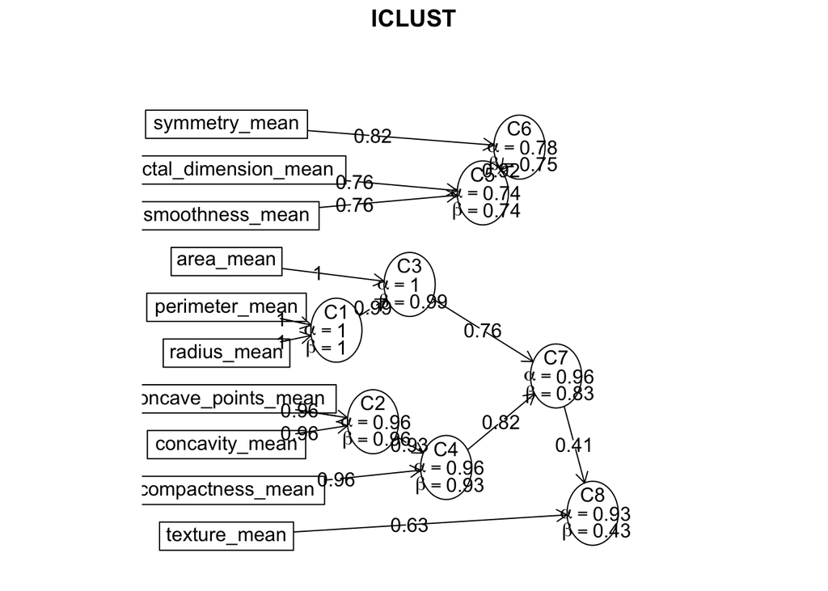

[output not shown]

```r
iclust(wdbc_mean, nclusters=2)
```